# Data Analysis Using Statistical Packages: Regression Analysis

Sho Kuroda / 黒田翔

最終更新：2026年5月

このページに対応するRmdファイル：[GitHub](https://github.com/kurodaecon/dasp/blob/main/rmd/regression.Rmd)

# 1 Data

このページで使用するデータは，カーセンサーnetという中古車情報サイトに掲載されている [人気車種ランキング](https://www.carsensor.net/ranking/pop/) Top 80 の車種に関する車種レベルの属性．

- ランキングはカーセンサーに掲載されている自動車への問い合わせデータに基づいて車種別に作成されている．
  - このページでは，車種とは「プリウス」（トヨタのハイブリッド車）とか「N-BOX」（ホンダのトールワゴン型軽自動車）のようなカテゴリーを指す語として用いる．
- 一般的に一つの車種には様々なバリエーションがあるが，そのうち一つを選択しその車種を代表する属性とした．
  - たとえば，トヨタのプリウスを例にとると，まず世代と呼ばれる区分けがあり（初代 1997～，2代目 2003～，3代目 2009～，4代目 2015～），さらに「Z」・「G」・「X」・「U」など幾つかのグレードに分かれ，そこからさらにハイブリッドかプラグインハイブリッドか，駆動方式が前輪駆動（FF）か四輪駆動（4WD）か，などの基準で枝分かれする．
  - 幾つかあるバリエーションのうちデータ入力者（黒田）がいずれを選択したか（の規則性）は分析結果に影響を及ぼすが，この演習ではそれは気にしないことにしよう．
- 2025年6月のランキングに基づいてデータを作成した．データセットにランクを表す列はないが，ランキングのとおり昇順で並んでいる（列名を表す行を除いて1行目が1位で，80行目が80位）．
- 変数
  - `model`: 車種
  - `maker`: 製造メーカー
  - `year`: 世代の開始年（一つ前の世代からモデルチェンジした年）［西暦］
  - `price`: 新車時価格（税込）［万円］
  - `seat`: 乗車定員
  - `length`: 全長［m］
  - `width`: 全幅［m］
  - `height`: 全高［m］
  - `weight`: 車両重量［kg］
  - `WLTC`: WLTCモード燃費［km/L］
  - `ps`: 最高出力［ps］ （注：ドイツ語の Pferdestärke の略で馬力の意．1 PS ≒ 0.74 kW）
  - `disp`: 排気量［cc］
  - `hybrid`: ハイブリッド車ダミー
  - `electric`: 電気自動車ダミー

```r
car <- read.csv("https://raw.githubusercontent.com/kurodaecon/dasp/refs/heads/main/data/carsensor_ranking_of_most_popular_car_models_asof202506.csv")
str(car)
```

```
## 'data.frame':    80 obs. of  14 variables:
##  $ model   : chr  "N-BOX" "Serena" "Prius" "Tanto" ...
##  $ maker   : chr  "Honda" "Nissan" "Toyota" "Daihatsu" ...
##  $ year    : int  2023 2022 2022 2019 2023 2024 2022 2022 2021 2019 ...
##  $ price   : num  174 362 299 148 555 ...
##  $ seat    : int  4 7 5 4 7 6 7 5 7 4 ...
##  $ length  : num  3.4 4.69 4.6 3.4 5 4.31 4.8 4.26 4.7 3.4 ...
##  $ width   : num  1.48 1.7 1.78 1.48 1.85 1.7 1.75 1.7 1.73 1.48 ...
##  $ height  : num  1.79 1.89 1.42 1.76 1.94 1.76 1.84 1.7 1.9 1.68 ...
##  $ weight  : int  910 1900 1360 880 2060 1460 1710 1280 1640 830 ...
##  $ WLTC    : num  21.6 17 32.6 22.7 10.6 25.6 13.2 18.4 23 25 ...
##  $ ps      : int  58 98 98 52 182 106 150 120 98 49 ...
##  $ disp    : int  658 1433 1797 658 2493 1496 1496 1490 1797 657 ...
##  $ hybrid  : int  0 1 1 0 0 1 0 0 1 0 ...
##  $ electric: int  0 0 0 0 0 0 0 0 0 0 ...
```

このページ全体を通した分析の目的は「車両の価格と属性の関係を定量的に記述すること」（+α）としよう． 因果推論は目的ではない．

## 1.1 Summary stats

長くなるのでこのページには結果を出力しない設定にしているが，実際にはこれを見ながらデータの分布と特徴を理解するのもデータ分析の重要な工程．

```r
summary(car[, c(-1, -2)])
table(car$maker)
car[car$maker == "Nissan", ]
car[car$maker %in% c("BMW", "Jeep", "Mercedes-Benz", "Porsche"), ]
hist(car$price)
hist(car$price[car$price <= 1000])
car[car$price > 1000, ]
table(car$seat)
table(car$hybrid)
table(car$electric)
car[car$electric == 1, ]
car[, c(-1, -2, -14)] |> cor(use = "complete.obs") |> round(2)  # "|>" = pipe in base R
# round(cor(car[, c(-1, -2, -14)], use = "complete.obs"), 2)  # same as above
plot(car[, c("price", "weight", "height", "WLTC", "ps", "year")])
```

## 1.2 Create variables

```r
car$accel <- car$ps / car$weight  # 加速性能の大まかな指標 (power-to-weight ratio)
car$kei <- 1 * (car$disp <= 660)  # 軽自動車ダミー
```

## 1.3 Trim dataset

次の車両は除外する：乗車定員が3以下（スポーツカー・軽トラック等）または6以上（ミニバン・ワゴン車），海外メーカー，1,000万円を超える自動車，電気自動車．

```r
car <- car[car$seat %in% 4:5, ]
car <- car[!(car$maker %in% c("BMW", "Jeep", "Mercedes-Benz", "Porsche")), ]
car <- car[car$price <= 1000, ]
car <- car[car$electric == 0, ]
# which(colnames(car) == "electric")  # 14
car <- car[, -14]  # remove "electric" variable (column)
nrow(car)  # sample size
```

```
## [1] 50
```

# 2 Simple regression analysis / 単回帰分析

1つの説明変数をもつ次のような回帰モデル（単回帰モデル）を考える．

$$\mbox{Price} = \alpha + \beta \
\mbox{Weight} + u$$

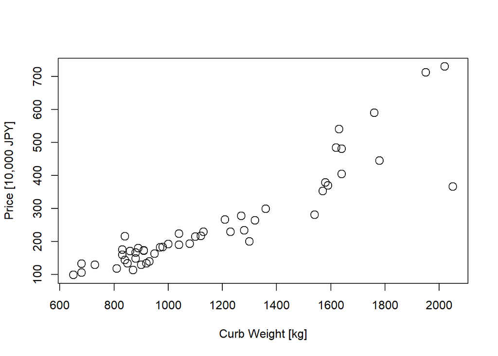

```r
plot(price ~ weight, car, cex = 1.5, xlab = "Curb Weight [kg]", ylab = "Price [10,000 JPY]")
```

上の `plot` 関数は `plot(formula = y ~ x, data = dataset)` の形式で変数を指定しており，`plot(x = dataset$x, y = dataset$y)` と同じ意味．

## 2.1 Estimation with `lm` function

`lm` (linear model) 関数で推定する．

```r
lm(formula = price ~ weight, data = car)
```

```
##
## Call:
## lm(formula = price ~ weight, data = car)
##
## Coefficients:
## (Intercept)       weight
##   -169.6602       0.3651
```

次のように `formula =` や `data =` を省略してもよい（出力は省略）．

```r
lm(price ~ weight, car)
```

以上の推定結果は以下のように回帰式が推定されたことを意味している．

$$\mbox{Price} = -170 + 0.37 \
\mbox{Weight} + u$$

`weight` の回帰係数は「`weight` が1単位大きい車種では `price` は 0.37 単位高い傾向にある」＝「車両重量が 1kg 重い車種の価格は3,700円高い」と解釈される．

- ある特定の車種について「設計を変更して `Weight` を1単位引き上げると `Price` を 0.37 単位引き上げることができる（市場適正価格が3,700円上昇する）」あるいは「政策的介入によって重量が1kg増加したら均衡価格が3,700円上昇する」などのように解釈することはできない．この回帰係数はあくまで両変数の相関的な関係を記述しているだけであり（注：相関係数とは異なる），因果関係を示すものではない．

次のように考えてもよい．

- `weight` = 1,000kg の平均価格（回帰直線上の予測価格）は $-170 + 0.37 \cdot 1000 = 200$ 万円
- `weight` = 1,100kg の平均価格は $-170 + 0.37 \cdot 1100 = 237$ 万円
  - 100kg で37万円差が付くので，1kg 当たり3,700円違う

説明変数が1つの場合，回帰式は下図のように散布図に書き足すことができる． 大雑把に言えば，回帰式の推定（＝回帰係数パラメタを計算すること）とはデータに当てはまる直線の切片 $\alpha$ と傾き $\beta$ を決める手続きである．

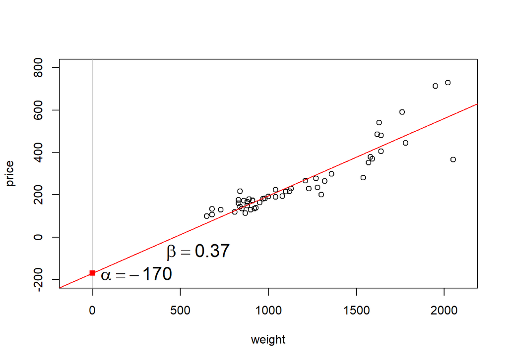

```r
plot(price ~ weight, car, xlim = c(-100, 2100), ylim = c(-200, 800))
abline(v = 0, col = "grey")  # Y-axis
abline(lm(price ~ weight, car), col = "red")
points(0, -169.66, pch = 15, col = "red")
text(250, -170, expression(alpha == -170), cex = 1.5)
text(600, -70, expression(beta == 0.37), cex = 1.5)
```

`lm` 関数で計算した回帰オブジェクトを `summary` 関数に渡すと決定係数なども表示される．

```r
summary(lm(price ~ weight, car))
```

```
##
## Call:
## lm(formula = price ~ weight, data = car)
##
## Residuals:
##      Min       1Q   Median       3Q      Max
## -212.197  -30.221   -5.594   27.261  170.713
##
## Coefficients:
##               Estimate Std. Error t value Pr(>|t|)
## (Intercept) -169.66019   29.72521  -5.708 6.99e-07 ***
## weight         0.36510    0.02422  15.075  < 2e-16 ***
## ---
## Signif. codes:  0 '***' 0.001 '**' 0.01 '*' 0.05 '.' 0.1 ' ' 1
##
## Residual standard error: 64.15 on 48 degrees of freedom
## Multiple R-squared:  0.8256, Adjusted R-squared:  0.822
## F-statistic: 227.3 on 1 and 48 DF,  p-value: < 2.2e-16
```

`Multiple R-squared` が決定係数，`Adjusted R-squared` が自由度調整済み決定係数を表す．

## 2.2 Estimation by hand

回帰モデル

$$Y_i = \alpha + \beta X_i + u_i$$

の係数パラメタ（$\alpha, \beta$）を最小二乗法（OLS）によって求めよう．

最小二乗法とは，誤差 $u = Y - (\alpha + \beta X_i)$ （推定では観察可能な残差 $\hat{u}_i = Y_i - \hat{Y}_i = Y_i - (\hat{\alpha}+\hat{\beta}X_i)$ を用いる）の二乗和を最小化するように係数パラメタを求める方法である．

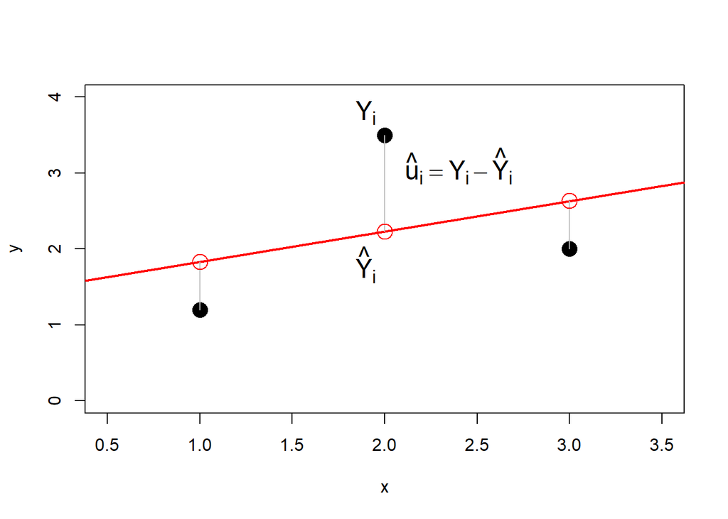

誤差の二乗和 $Q$ は以下で与えられる．

$$Q = \sum_{i} u_i^2 = \sum_{i} (Y_i -
\alpha - \beta X_i)^2$$

$Q$ は $\alpha, \beta$ のいずれについても下に凸の関数であるので，$Q$ をそれぞれで微分して 0 とおく．

$$\frac{\partial Q}{\partial \alpha} = -2
\sum_i (Y_i - \alpha - \beta X_i) = 0$$

$$\frac{\partial Q}{\partial \beta} = -2
\sum_i X_i (Y_i - \alpha - \beta X_i) = 0$$

上の連立方程式を解くことによって，最小二乗推定量は次のように与えられる．

$$\hat{\alpha} = \bar{Y} - \hat{\beta}
\bar{X}, \quad \hat{\beta} = \frac{S_{XY}}{S_{XX}}$$
$$S_{XX} = \sum_i (X_i - \bar{X})^2, \quad S_{XY}
= \sum_i (X_i - \bar{X}) (Y_i - \bar{Y})$$

$\bar{Y}, \bar{X}, S_{XX}, S_{XY}$ という4つの統計量は次のように計算できる．

```r
x <- car$weight
y <- car$price
y_bar <- mean(y)  # Y bar
x_bar <- mean(x)  # X bar
s_xx <- sum((x - x_bar)^2)  # S_XX
s_xy <- sum((x - x_bar) * (y - y_bar))  # S_XY
c(y_bar, x_bar, s_xx, s_xy)
```

```
## [1]     257.07    1168.80 7015928.00 2561523.20
```

計算した統計量を使って回帰係数を計算する．

```r
beta_hat <- s_xy / s_xx
alpha_hat <- y_bar - beta_hat * x_bar
c(alpha_hat, beta_hat)
```

```
## [1] -169.6601939    0.3651011
```

## 2.3 Estimation by numerical calculation / 数値計算による推定

OLSは残差二乗和の最小化によって回帰係数パラメタを推定する方法（モデルをデータに当てはめる原理）であるが，これを解析的に解くのではなく数値計算によって解いてみる．

残差二乗和の関数（目的関数） $Q$ の最小化は R に built-in されている汎用の最適化関数 `optim` によって行う．

### 2.3.1 Example of `optim`

例：次の二次関数は $x=2$ で最小値 3 をとる．

$$f(x) = x^2 -4x + 7 = (x-2)^2 + 3$$

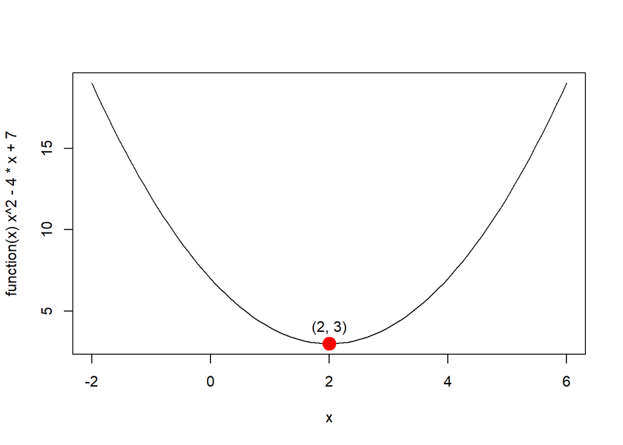

最小値を取るような $x$ の値を `optim` 関数を使って求めてみる．

- `optim(par = パラメタの初期値ベクトル, fn = 目的関数)` の形で指定
  - `$par` ：最適化されたパラメタ（＝目的関数の引数；この例では $x$）
  - `$value` ：最小化された目的関数の値
  - `$convergence` ： 最適化計算が収束していれば 0

```r
obj_function <- function (x) x^2 - 4*x + 7
optim(par = 0, fn = obj_function, method = "BFGS")  # 準ニュートン法を利用
```

```
## $par
## [1] 2
##
## $value
## [1] 3
##
## $counts
## function gradient
##        6        3
##
## $convergence
## [1] 0
##
## $message
## NULL
```

なお，ニュートン法は次の更新式を用いて実装できる．

$$x_{\mbox{new}} = x -
\frac{f'(x)}{f''(x)} = x - \frac{2x-4}{2} = 2$$

- 今扱っている目的関数は単純な二次式なので初期値によらず1回の更新で収束するが，通常は何度も更新を繰り返す．

```r
grad_f <- function (x) 2 * x - 4  # 目的関数の1階微分（勾配）
newton_method <- function (initial) {
  x <- initial
  for (i in 1:10) {  # 10 = max iteration
    step <- grad_f(x) / 2  # 分母の2 = 目的関数の2階微分（Hessian）
    x_new <- x - step
    cat("i=", i, ", f'=", grad_f(x), ", f'/f''=", step, ", x=", x,
        ", x_new=", x_new, ", Δx=", x_new - x, "\n", sep = "")
    if (abs(x_new - x) < 0.01) return(x_new)  # 0.01 = tolerance
    x <- x_new
  }
  cat("Not converged")
}
newton_method(initial = 10)
```

```
## i=1, f'=16, f'/f''=8, x=10, x_new=2, Δx=-8
## i=2, f'=0, f'/f''=0, x=2, x_new=2, Δx=0
```

```
## [1] 2
```

### 2.3.2 In the case of regression

回帰分析の場合，目的関数は残差二乗和 $Q$ であり，その引数は推定したい回帰係数パラメタ $(\alpha, \beta)$ となる．

$$(\hat{\alpha}, \hat{\beta}) = \arg
\min_{\alpha, \beta} Q(\alpha, \beta)$$
$$Q (\alpha, \beta) := \sum_i u_i^2 = \sum_i (Y_i
- \alpha - \beta X_i)^2$$

```r
sum_of_squared_residuals <- function(coef_vector) {
  # coef_vector[1]: alpha (intercept)
  # coef_vector[2]: beta (slope of X)
  sum((y - coef_vector[1] - coef_vector[2] * x)^2)
}
sum_of_squared_residuals(coef_vector = c(0, 1))  # alpha=0, beta=1
```

```
## [1] 44588206
```

```r
sum_of_squared_residuals(coef_vector = c(0, 0.5))  # alpha=0, beta=0.5
```

```
## [1] 5682450
```

```r
optim(par = c(0, 0), fn = sum_of_squared_residuals)
```

```
## $par
## [1] -169.6753516    0.3651259
##
## $value
## [1] 197529.7
##
## $counts
## function gradient
##      107       NA
##
## $convergence
## [1] 0
##
## $message
## NULL
```

$\hat{\alpha} = -170$ に固定して $\hat{\beta}$ の値によって残差二乗和がどのように変化するかをプロットすると，$\hat{\beta} = 0.37$ で最小化されていることが分かる．

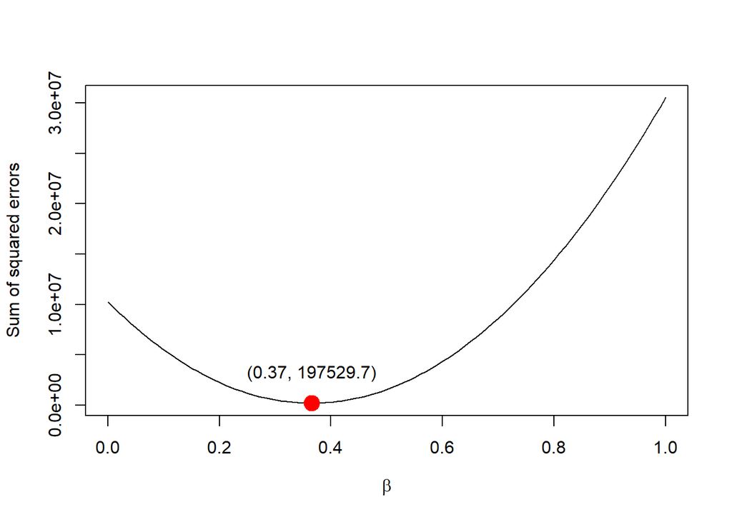

## 2.4 Coefficient of determination / 決定係数

$$R^2 = \frac{\mbox{Variation in } Y
\mbox{ explained by } X}{\mbox{Total variation in } Y} =
\frac{S_{\hat{Y}\hat{Y}}}{S_{YY}} = 1 - \frac{\sum \hat{u}_i^2}{S_{YY}}$$

$$S_{YY} = \sum_i (Y_i - \bar{Y})^2,
\quad S_{\hat{Y} \hat{Y}} = \sum_i (\hat{Y}_i - \bar{\hat{Y}})^2$$

```r
s_yy <- sum((y - y_bar)^2)
y_pred <- alpha_hat + beta_hat * x  # y hat
s_yhyh <- sum((y_pred - y_bar)^2)
c(s_yhyh, s_yy)
```

```
## [1]  935215 1132745
```

```r
s_yhyh / s_yy  # R^2
```

```
## [1] 0.8256185
```

```r
res <- y - y_pred  # residuals
1 - sum(res^2) / s_yy  # R^2 ... should be the same as above
```

```
## [1] 0.8256185
```

決定係数が 0.83 であることは「説明変数 (`weight`) によって被説明変数 (`price`) の変動のうち 83% を説明することができる」という意味．

余裕のある履修者向けの宿題：自由度調整済み決定係数を計算．

$$\bar{R}^2 = 1 - \frac{n - 1}{n - K - 1}
\frac{\sum \hat{u}_i^2}{S_{YY}}$$

$K$: 説明変数の数（定数項は含めない）

ヒント：$n$ は `nrow(car)` で与えられる（欠損値があればその分の調整も必要）．

## 2.5 Standard error and test / 標準誤差と検定

帰無仮説「$H_0: \beta = 0$」の検定を行うために，$\hat{\beta}$ の標準誤差（s.e.）を求める．

$$V(\hat{\beta}) =
\frac{\sigma^2}{S_{XX}}, \quad s.e.(\hat{\beta}) = \sqrt{V(\hat{\beta})}$$

誤差分散 $\sigma^2$ は残差 $\hat{u}$ を利用して次のように推定する．

$$\hat{\sigma}^2 = s^2 = \frac{1}{n - 2}
\sum \hat{u}_i^2$$

```r
n <- nrow(car)  # sample size
res <- y - (alpha_hat + beta_hat * x)  # redefine: residuals
s2 <- sum(res^2) / (n - 2)  # estimated sigma^2
s2
```

```
## [1] 4115.202
```

```r
beta_se <- sqrt(s2 / s_xx)  # standard error
beta_se
```

```
## [1] 0.02421882
```

$$t =
\frac{\hat{\beta}}{\sqrt{V(\hat{\beta})}}$$

```r
beta_hat / beta_se  # t-value
```

```
## [1] 15.0751
```

$$p = 2 \times [ 1 - \Pr(T \le |t|) ]$$

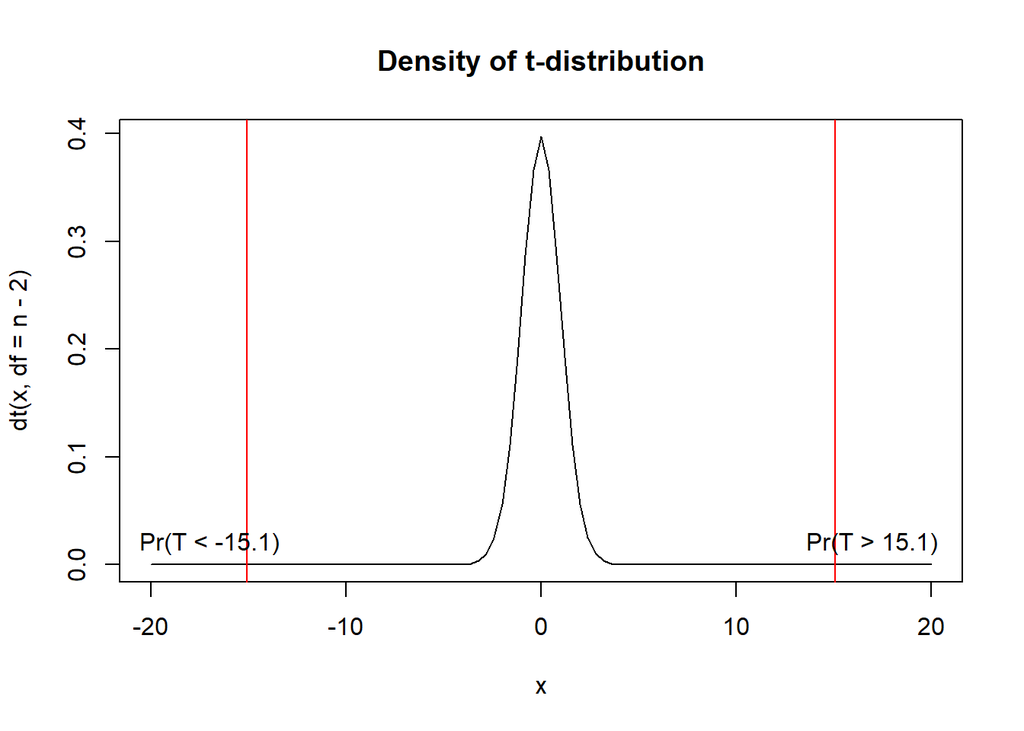

```r
curve(dt(x, df = n - 2), from = -20, to = 20, main = "Density of t-distribution")
abline(v = beta_hat / beta_se * c(-1, 1), col = "red")
text(c(-17, 17), 0.02, labels = c("Pr(T < -15.1)", "Pr(T > 15.1)"))
```

$t$ 値が大きすぎるので上の図の中で $\Pr(T > 15.1)$ の領域が見えないが，拡大すると以下のようになる． 青色の領域の面積が片側 $p$ 値となる．

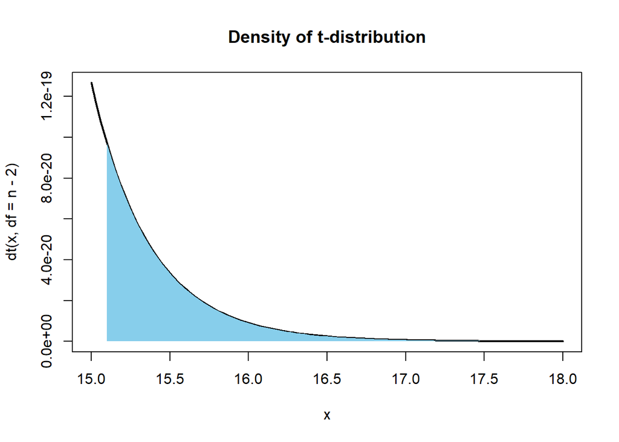

上の青の領域の面積を2倍したものが $p$ 値．

```r
2 * (1 - pt(q = beta_hat / beta_se, df = n - 2))
```

```
## [1] 0
```

注：あまりにも小さいので 0 と表示されているが，厳密には 0 ではない．このような場合，論文・レポート等では「$p < 0.001$」（表中では「$< 0.001$」）のように書くことで，厳密には0ではないものの 0.1% 水準で有意であることが報告できる．

### 2.5.1 Critical value approach / 臨界値を用いて検定を行う場合

例として，有意水準 $\alpha = 0.05$ と設定した場合を考えよう．

t分布の97.5%分位点（両側5%に対応する臨界値）は `qt` 関数で計算できる．

```r
qt(p = 0.975, df = n - 2)  # df: degree of freedom (自由度)
```

```
## [1] 2.010635
```

```r
qt(p = c(0.975, 0.995, 0.9995), df = n - 2)  # 5%, 1%, and 0.1%
```

```
## [1] 2.010635 2.682204 3.505068
```

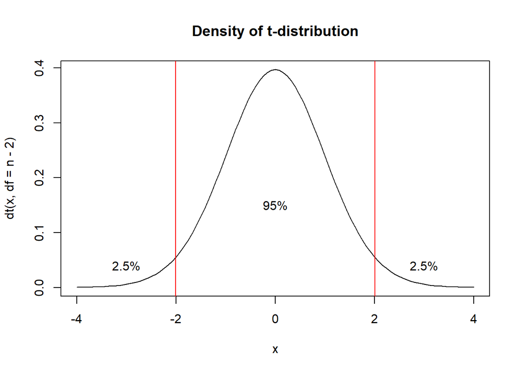

```r
curve(dt(x, df = n - 2), from = -4, to = 4, main = "Density of t-distribution")
abline(v = c(-2.01, 2.01), col = "red")
text(c(-3, 3), 0.04, labels = "2.5%"); text(0, 0.15, labels = "95%")
```

よって，$t = 15.1$ は有意水準5%に対応する臨界値 (2.01) よりも大きいので，5%水準で有意と言える．

- 同様に考えて $t = 15.1$ であれば1%でも0.1%でも有意なので，論文・レポートでは「変数 $X_j$ の回帰係数は0.1%水準で有意（に0と異なる）」と書く場合もある．これは，単に帰無仮説（$\beta_j = 0$）を棄却するかどうかの二値的な情報だけでなく，その結論の確実性がどの程度高いか（← 非常にラフな表現）という情報を報告する意図があるものと思われる．ただし，このことは「有意になるように（あるいは有意にならないように），$p$ 値を計算した後に有意水準を設定してよい」ことを意味しない．
- Rでは非常に小さい $p$ 値が `2e-16` のように表示される場合があるが，これをそのまま「$p = 2\times10^{-16}$」のようにレポートするのはNG．`2e-16` という厳密な数値が計算されているわけではなくて，数値計算上の精度の限界によりこれより小さい値である（$p < 2\times10^{-16}$）ことしか分からないという意味である．そして，この場合の $2$ あるいは $10^{-16}$ という数値の厳密な値は実務上ほとんど意味をなさない．たとえば，これが $2.5 \times 10^{-15}$ であったとしても仮説検定の結論は何も変わらない．よって，このような場合は「$p < 0.001$」と書けば十分である．

自由度が大きければ標準正規分布の場合とほとんど同じ臨界値になる．

```r
c(qt(p = 0.975, df = 10000), qnorm(p = 0.975))
```

```
## [1] 1.960201 1.959964
```

### 2.5.2 MC Simulation

回帰係数パラメタについて帰無仮説を $\beta=0$ としたときの検定における第一種の過誤について，シミュレーションを通じて考えよう．

$\beta = 0$ の設定でデータを生成し，その回帰係数の $t$ 値の分布と第一種の過誤を確認してみよう．

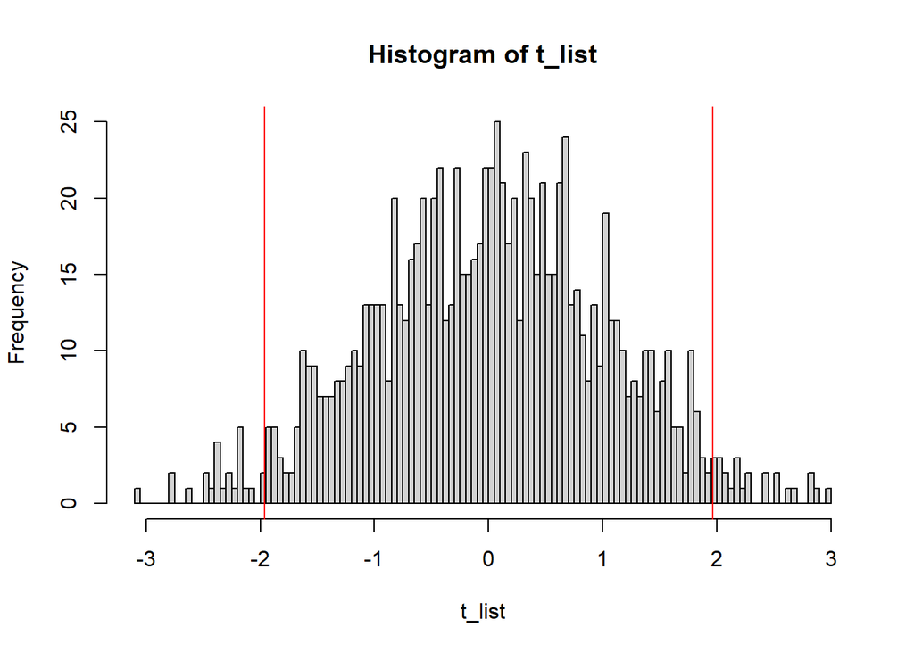

```r
t_list <- NULL
for (i in 1:1000) {
  set.seed(100*i)  # 弥縫策
  x_i <- 1:1000
  y_i <- 1 + 0 * x_i + rnorm(1000)  # x_i の係数を 0 に設定
  t_i <- summary(lm(y_i ~ x_i))$coef["x_i", "t value"]
  t_list <- c(t_list, t_i)
}
# qt(p = 0.975, df = 1000 - 2)  # 1.962344
hist(t_list, breaks = 100)
abline(v = qt(p = c(0.025, 0.975), df = 1000 - 2), col = "red")
```

```r
table(t_list <= -1.962 | t_list >= 1.962)  # TRUE = 第一種の過誤
```

```
##
## FALSE  TRUE
##   953    47
```

### 2.5.3 Robust standard error / 頑健な標準誤差

詳しい議論はこの授業では行わないが，標準誤差は誤差項の不均一分散を前提として計算した方がよい．

`fixest` パッケージの `feols` 関数が便利． 下のように`vcov` オプションを指定する．

```r
# install.packages("fixest")
library(fixest)
fixest::feols(price ~ weight, car, vcov = "hetero")  # HC1
```

```
## OLS estimation, Dep. Var.: price
## Observations: 50
## Standard-errors: Heteroskedasticity-robust
##                Estimate Std. Error  t value   Pr(>|t|)
## (Intercept) -169.660194  43.287229 -3.91941 2.8103e-04 ***
## weight         0.365101   0.042941  8.50237 3.8751e-11 ***
## ---
## Signif. codes:  0 '***' 0.001 '**' 0.01 '*' 0.05 '.' 0.1 ' ' 1
## RMSE: 62.9   Adj. R2: 0.821986
```

$\beta = 0$ かつ不均一な誤差分散をもつモデルに基づいてデータを生成し，第一種の過誤を通常のSE vs. 頑健なSEで比較してみよう．

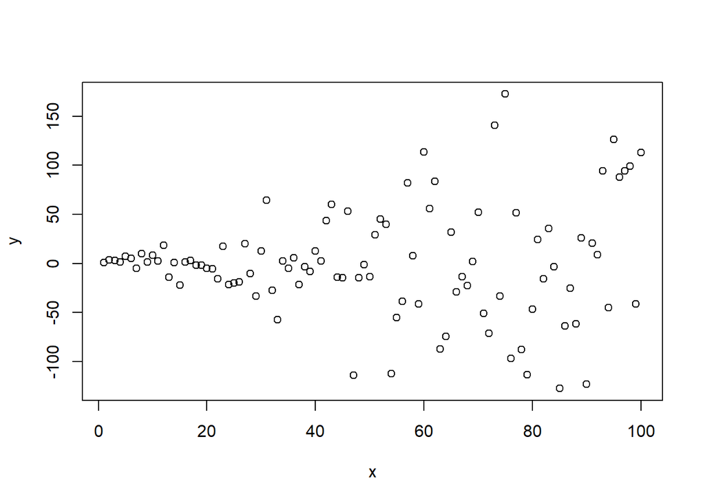

```r
plot(x = 1:100, y = 1 + rnorm(100, sd = 1:100), xlab = "x", ylab = "y")
```

```r
t_list <- t_r_list <- NULL
for (i in 1:1000) {
  set.seed(i)
  data_i <- data.frame(
    x_i = 1:1000,
    y_i = 1 + 0 * (1:1000) + rnorm(1000, sd = 1:1000)
  )
  t_i <- fixest::feols(y_i ~ x_i, data_i)$coeftable["x_i", "t value"]
  t_r_i <- fixest::feols(y_i ~ x_i, data_i, vcov = "hetero")$coeftable["x_i", "t value"]
  t_list <- c(t_list, t_i)
  t_r_list <- c(t_r_list, t_r_i)
}
qt(p = 0.975, df = 1000-1)
```

```
## [1] 1.962341
```

```r
table(t_list <= -1.962 | t_list >= 1.962)  # 第一種の過誤が5%を超える
```

```
##
## FALSE  TRUE
##   928    72
```

```r
table(t_r_list <= -1.962 | t_r_list >= 1.962)  # 5%がTRUEになるはず -> 概ねOK
```

```
##
## FALSE  TRUE
##   951    49
```

### 2.5.4 Cluster-robust standard error / クラスター頑健標準誤差

`vcov = ~ cluster` の形式でオプションを指定する．

```r
fixest::feols(price ~ weight, car, vcov = ~ maker)
```

```
## OLS estimation, Dep. Var.: price
## Observations: 50
## Standard-errors: Clustered (maker)
##                Estimate Std. Error  t value   Pr(>|t|)
## (Intercept) -169.660194  31.124525 -5.45101 1.5859e-03 **
## weight         0.365101   0.027755 13.15432 1.1913e-05 ***
## ---
## Signif. codes:  0 '***' 0.001 '**' 0.01 '*' 0.05 '.' 0.1 ' ' 1
## RMSE: 62.9   Adj. R2: 0.821986
```

上記を regression table の形式で比較するには `huxtable` パッケージを使うと便利．

- 推定値の下段の丸カッコが標準誤差を示す．
- `modelsummary` パッケージが使えればそちらでもよい．黒田の環境ではうまくいかなかったのでこのページでは `huxtable` で代用．

```r
# install.packages("huxtable")
library(huxtable)
lm0 <- fixest::feols(price ~ weight, car)
lm1 <- fixest::feols(price ~ weight, car, vcov = "hetero")
lm2 <- fixest::feols(price ~ weight, car, vcov = ~ maker)
huxtable::huxreg("Classical SE" = lm0, "Robust SE" = lm1, "Clustered SE" = lm2)
```

[output not shown]

# 3 Multiple regression analysis / 重回帰分析

2つの説明変数をもつ次のような回帰モデル（重回帰モデル）を考える．

$$\mbox{Price} = \alpha + \beta_1 \
\mbox{Weight} + \beta_2 \ \mbox{PS} + u$$

```r
summary(lm(price ~ weight + ps, car))
```

```
##
## Call:
## lm(formula = price ~ weight + ps, data = car)
##
## Residuals:
##      Min       1Q   Median       3Q      Max
## -141.669  -26.642    2.186   17.320  211.752
##
## Coefficients:
##               Estimate Std. Error t value Pr(>|t|)
## (Intercept) -103.71044   31.12576  -3.332 0.001708 **
## weight         0.23679    0.03844   6.160 1.67e-07 ***
## ps             0.77649    0.19347   4.014 0.000218 ***
## ---
## Signif. codes:  0 '***' 0.001 '**' 0.01 '*' 0.05 '.' 0.1 ' ' 1
##
## Residual standard error: 56.39 on 46 degrees of freedom
##   (1 observation deleted due to missingness)
## Multiple R-squared:  0.8686, Adjusted R-squared:  0.8629
## F-statistic: 152.1 on 2 and 46 DF,  p-value: < 2.2e-16
```

`weight` の係数は「`ps` の水準を固定したもとで `weight` が1単位高い値を取ると `price` は 0.24 単位高い値を取る傾向にある」≒「馬力が同じ自動車同士で比較すると，車両が 1kg 重い自動車の価格は 2,400 円高い」と解釈される．

なお，「単回帰分析では因果関係が推定できないが，重回帰分析では因果関係が推定できる」という主張は一般には誤り．

- 重回帰分析によって因果効果を推定するためには，処置変数の条件付き独立性（かなり大雑把に言うと，交絡変数がすべてコントロール変数として正確な関数形でモデルに含められていること）が成立していなければならず，この仮定を社会経済データを用いた実証分析において満たすことは容易ではない．

## 3.1 $X \to Y$ の効果（のようなもの）を推定したい場合

観察データに基づく回帰分析で $X \to Y$ の因果効果を推定するという目標を達成することは通常困難ではあるが，適切なコントロール変数を加えることで少しでも目標に近づこうとする試みは社会科学一般で広くみられる．

自動車価格の分析においては因果推論を目的としないので，このサブセクションでは仮想データでのシミュレーションのみ行う．

### 3.1.1 Confounder / 交絡変数

「$X \leftarrow W \to Y$」のような変数 $W$ を交絡変数（または交絡因子）と呼ぶ． このような変数はコントロールしなければならない．

例：

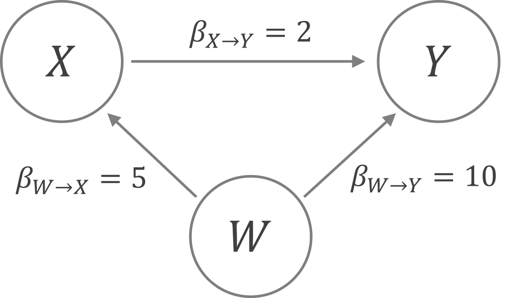

```r
set.seed(0)
w <- rnorm(n = 100)
x <- 5 * w + rnorm(n = 100)
y <- 10 * w + 2 * x + rnorm(n = 100, sd = 5)
# pairs(data.frame(x, y, w))
summary(lm(y ~ x))$coef
```

```
##              Estimate Std. Error    t value     Pr(>|t|)
## (Intercept) 0.4318837  0.5640379  0.7656997 4.456953e-01
## x           3.9310510  0.1222709 32.1503526 7.290409e-54
```

```r
summary(lm(y ~ x + w))$coef
```

```
##               Estimate Std. Error   t value     Pr(>|t|)
## (Intercept)  0.3226362  0.5311195 0.6074645 0.5449621667
## x            1.9038566  0.5564695 3.4213134 0.0009135961
## w           10.8817467  2.9226286 3.7232739 0.0003300614
```

- $W$ をコントロールしない場合：$X$ の係数の推定値にバイアスが生じる（$X$ と $Y$ が共有する $W$ の変分も含めた値が推定されるため）
- $W$ をコントロールする場合：$X$ の係数の推定値にバイアスは見られない

### 3.1.2 Mediator / 媒介変数

「$X \to W \to Y$」のような変数 $W$ を媒介変数と呼ぶ．

- $X$ から $Y$ への全体効果（直接効果 $\beta_{X \to Y}$ と間接効果 $\beta_{X \to W} \times \beta_{W \to Y}$ を合わせた効果）を推定したい場合：$W$ はコントロールしない
- $X$ から $Y$ への直接効果 $\beta_{X \to Y}$ のみを推定したい場合：$W$ をコントロールする

詳しくは [VanderWeele (Annual Review of Public Health 2016)](https://doi.org/10.1146/annurev-publhealth-032315-021402) を参照．

例：

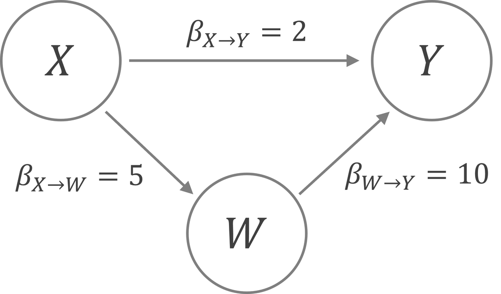

```r
set.seed(0)
x <- rnorm(n = 100)
w <- 5 * x + rnorm(n = 100)
y <- 2 * x + 10 * w + rnorm(n = 100)
# pairs(data.frame(x, y, w))
summary(lm(y ~ x))$coef
```

```
##               Estimate Std. Error    t value     Pr(>|t|)
## (Intercept) -0.4215146  0.9668058 -0.4359868 6.638052e-01
## x           53.4654849  1.1004958 48.5830865 2.201406e-70
```

```r
summary(lm(y ~ x + w))$coef
```

```
##               Estimate Std. Error    t value     Pr(>|t|)
## (Intercept) 0.06452725  0.1062239  0.6074645 5.449622e-01
## x           2.17634935  0.5845257  3.7232739 3.300614e-04
## w           9.98077132  0.1112939 89.6794065 4.024333e-95
```

- $W$ をコントロールしない場合：直接効果 $\beta_{X \to Y} = 2$ と間接効果 $\beta_{X \to W} \times \beta_{W \to Y} = 5 \times 10 = 50$ を合わせたものが推定される
- $W$ をコントロールする場合：$X \to Y$ の直接効果 $\beta_{X \to Y} = 2$ のみ推定される

### 3.1.3 Collider / 合流点

「$X \to W \leftarrow Y$」のような変数 $W$ を collider と呼ぶ． このような変数はコントロールしてはならない．

例：

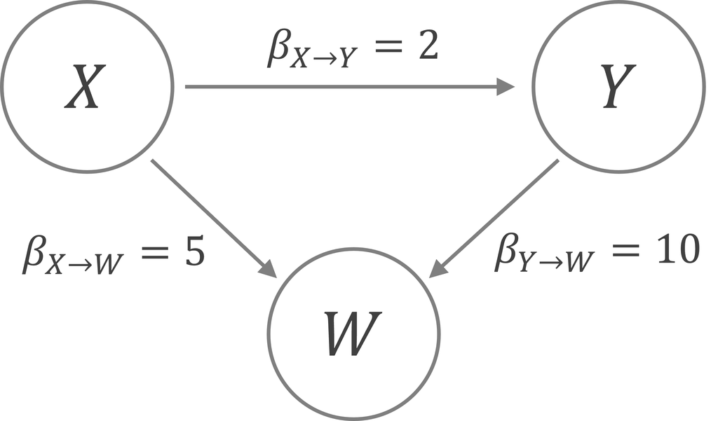

```r
set.seed(0)
x <- rnorm(n = 100)
y <- 2 * x + rnorm(n = 100)
w <- 5 * x + 10 * y + rnorm(n = 100, sd = 5)
# pairs(data.frame(x, y, w))
summary(lm(y ~ x))$coef
```

```
##                Estimate Std. Error    t value     Pr(>|t|)
## (Intercept) -0.04869782 0.09628791 -0.5057522 6.141664e-01
## x            2.13879478 0.10960262 19.5140842 1.571755e-35
```

```r
summary(lm(y ~ x + w))$coef
```

```
##                Estimate  Std. Error    t value     Pr(>|t|)
## (Intercept) -0.03635619 0.046866207 -0.7757442 4.397873e-01
## x            0.06905281 0.127942593  0.5397172 5.906290e-01
## w            0.07729946 0.004343237 17.7976622 2.572775e-32
```

- $W$ をコントロールしない場合：$X$ の係数の推定値にバイアスは見られない
- $W$ をコントロールする場合：$X$ の係数の推定値にバイアスが生じる

## 3.2 Multicollinearity / 多重共線性

### 3.2.1 Example of perfect multico. / 完全な多重共線性の例

$$\mbox{Price} = \alpha + \beta_1 \
\mbox{Weight} + \beta_2 \ (2 \times \mbox{Weight}) + u$$

```r
head(car$weight)
```

```
## [1]  910 1360  880 1280  830  730
```

```r
car$w2 <- 2 * car$weight
head(car$w2)
```

```
## [1] 1820 2720 1760 2560 1660 1460
```

```r
cor(car$weight, car$w2)
```

```
## [1] 1
```

```r
lm(price ~ weight + w2, car)$coef
```

```
##  (Intercept)       weight           w2
## -169.6601939    0.3651011           NA
```

R では，該当する変数（のうち一つ）が自動的に drop される．

### 3.2.2 Example of imperfect multico. / 不完全な多重共線性の例

互いに強い相関関係にある `weight`, `length`, `width` という3つの変数に着目しよう． いずれの変数も `price` と正の相関を持ち，単回帰分析では正の回帰係数を得る．

しかしながら，3つの変数を一つの回帰式に説明変数として同時に含めると，いずれの変数も標準誤差が大きくなる． ラフに言えば，これは推定が安定しなくなることを意味する． 実際，`width` の回帰係数は有意に負の値をとっているが，これは解釈しにくい結果である．

```r
car[, c("price", "weight", "length", "width")] |> cor() |> round(2)
```

```
##        price weight length width
## price   1.00   0.91   0.86  0.80
## weight  0.91   1.00   0.94  0.91
## length  0.86   0.94   1.00  0.97
## width   0.80   0.91   0.97  1.00
```

```r
# round(cor(car[, c("price", "weight", "length", "width")]), 2)  # same as above
lm0 <- lm(price ~ weight, car)
lm1 <- lm(price ~ length, car)
lm2 <- lm(price ~ width, car)
lm3 <- lm(price ~ weight + length + width, car)
huxtable::huxreg(lm0, lm1, lm2, lm3)
```

|  | (1) | (2) | (3) | (4) |
| --- | --- | --- | --- | --- |
| (Intercept) | -169.660 *** | -635.980 *** | -974.501 *** | 75.468 |
|  | (29.725) | (77.217) | (135.563) | (164.080) |
| weight | 0.365 *** |  |  | 0.330 *** |
|  | (0.024) |  |  | (0.073) |
| length |  | 225.199 *** |  | 160.922 |
|  |  | (19.270) |  | (86.590) |
| width |  |  | 746.497 *** | -510.580 * |
|  |  |  | (81.783) | (240.597) |
| N | 50 | 50 | 50 | 50 |
| R2 | 0.826 | 0.740 | 0.634 | 0.841 |
| logLik | -277.987 | -287.979 | -296.490 | -275.644 |
| AIC | 561.975 | 581.958 | 598.980 | 561.288 |
| *** p < 0.001; ** p < 0.01; * p < 0.05. |  |  |  |  |

### 3.2.3 VIF for diagnostics / VIF による診断

変数 $j$ の分散拡大係数（variance inflation factor, VIF）は，変数 $j$ をそれ以外の変数に回帰したときの決定係数 $R_j^2$ を使って以下のように計算される．

$$VIF_j = \frac{1}{1 - R_j^2}$$

経験則として「$VIF > 10$ ならば多重共線性が生じている」と判断されることが多い．

たとえば $j =$ `length` としてこの変数のVIFを計算してみよう．

```r
lm_length <- lm(length ~ weight + width, car)
r2_length <- summary(lm_length)$r.squared  # cf. str(summary(lm_length))
1 / (1 - r2_length)  # VIF
```

```
## [1] 31.69281
```

`car` パッケージの `vif` 関数を使うと便利． なお，このパッケージ名がデータセットを格納しているオブジェクト名と同じなので少しだけややこしいが，パッケージの方の名称は An R **C**ompanion to **A**pplied **R**egression という書籍名から来ている．

```r
# install.packages("car")
library(car)
car::vif(lm(price ~ weight + length + width, car))
```

```
##    weight    length     width
##  9.449551 31.692806 19.094157
```

多重共線性への対処：

- 深刻な多重共線性が生じている場合は該当する変数のうち（少なくとも）一つをモデルから外すことがある．とりわけ予測モデルとして回帰モデルを推定する際は変数の除去は珍しくない．予測が目的の場合は，相関が高い変数を合成しそれを説明変数としてモデルに加える場合もあるだろう．
- 一方で key variable $X_1$ がアウトカムに与える因果効果を測ろうとして回帰モデルを推定する場合に，$X_1$ と相関がある（かつアウトカムに影響を与える）変数 $X_2$ を除外すると除外変数バイアスが生じる可能性があるため，$X_2$ は除外するべきではないだろう．
  - ただし，$X_2$ が $X_1$ の影響を受ける変数でありかつアウトカムに影響を与える変数である場合に，$X_1$ がアウトカムに与える効果（$X_1$ から直接与える効果と $X_2$ を経由して間接的に与える効果の両方を合計したもの）を推定したい場合は，むしろ $X_2$ は除外するべきである．これは多重共線性とは別の理由による（いわゆる bad control の問題）．

## 3.3 Comparing the size of the coefficients / 回帰係数の大きさを比較する

例：`weight` と `ps` の回帰係数の（絶対値の）大きさを比較する．

```r
lm(price ~ weight + ps, car)$coef
```

```
##  (Intercept)       weight           ps
## -103.7104391    0.2367862    0.7764891
```

上の結果から「$|0.24| < |0.78|$ なので `ps` の方が `price` の変動をより説明する」と結論付けることはできない．

なぜなら，係数の大きさは変数のスケール（ばらつき）に依存するから．

たとえば，線形モデル $y = \beta_0 + \beta_1 x + u$ において金額ベースの変数 $x$ の単位を「円」から「千円」に変えると，推定される値そのもの ($\hat{\beta}_1$) は1千倍になるが，推定された回帰係数の「解釈」は全く変わらない（この変数の重要性が1千倍になるわけではない）．

### 3.3.1 Comparing the change per one SD / 1標準偏差当たりの変化量の比較

```r
c(0.24 * sd(car$weight), 0.78 * sd(car$ps, na.rm = TRUE))
```

```
## [1] 90.81462 58.69636
```

「$|90.8| > |58.7|$ なので `weight` の方が `price` の変動とより強く関連している」と言える．

### 3.3.2 Standardized partial regression coefficient / 標準偏回帰係数

より一般的な方法は，標準化（平均 0，分散 1 になるように変換）した変数を使って回帰分析をするもの．

```r
car$price_s <- (car$price - mean(car$price)) / sd(car$price)
car$weight_s <- (car$weight - mean(car$weight)) / sd(car$weight)
car$ps_s <- (car$ps - mean(car$ps, na.rm = TRUE)) / sd(car$ps, na.rm = TRUE)
c(mean(car$price_s), mean(car$weight_s), mean(car$ps_s, na.rm = TRUE))  # should be 0
```

```
## [1]  5.140202e-17  1.151509e-16 -3.661506e-17
```

```r
c(sd(car$price_s), sd(car$weight_s), sd(car$ps_s, na.rm = TRUE))  # should be 1
```

```
## [1] 1 1 1
```

```r
lm(price_s ~ weight_s + ps_s, car)$coef
```

```
## (Intercept)    weight_s        ps_s
## 0.007155726 0.589295242 0.384312017
```

「$|0.59| > |0.38|$ なので，相対的には `weight` の方が `price` の変動をよりよく説明している」くらいのことは言える．

ただし，以上の説明は厳密でも明瞭でもないので，レポート・論文での利用は推奨できない．

なお，t 値と p 値は標準化の前後で不変．

スケーリング（分散を 1 にする）とセンタリング（平均を 0 にする）を同時に行ってくれる `scale` という関数を使えばより簡単．

```r
lm(price ~ weight + ps, as.data.frame(scale(car[, c(-1, -2)])))
```

（出力は省略）

# 4 Variable transformation / 変数変換

## 4.1 Dummy variables / ダミー変数

`hybrid` 変数は，ハイブリッド車のときに 1 をとるダミー変数である． ハイブリッド車以外であるガソリン車やディーゼル車で 0 をとる．

$$\mbox{Price} = \alpha + \beta \
\mbox{Hybrid} + u$$

```r
table(car$hybrid)
```

```
##
##  0  1
## 45  5
```

```r
lm(price ~ hybrid, car)
```

```
##
## Call:
## lm(formula = price ~ hybrid, data = car)
##
## Coefficients:
## (Intercept)       hybrid
##      249.38        76.86
```

この回帰係数 77 は「ハイブリッド車はハイブリッド車以外と比較して平均的に 77 万円高い」ことを意味している（ただし統計的に有意ではない）．

```r
mean(car$price[car$hybrid == 0])
```

```
## [1] 249.3844
```

```r
mean(car$price[car$hybrid == 1])
```

```
## [1] 326.24
```

```r
mean(car$price[car$hybrid == 1]) - mean(car$price[car$hybrid == 0])
```

```
## [1] 76.85556
```

下の図のように理解できるだろう．

- 「□」は `hybrid` の値ごとの平均価格を表しており，これは回帰式に基づいて計算される価格の予測値（当てはめ値）に等しい．
  - `hybrid = 0` のとき，価格の予測値は $249 + 77 \cdot 0 = 249$ 万円（すなわち，切片の推定値そのもの）
  - `hybrid = 1` のとき，価格の予測値は $249 + 77 \cdot 1 = 326$ 万円
- 傾きは $\Delta y / \Delta x = (326 - 249) / 1 = 77$ である．

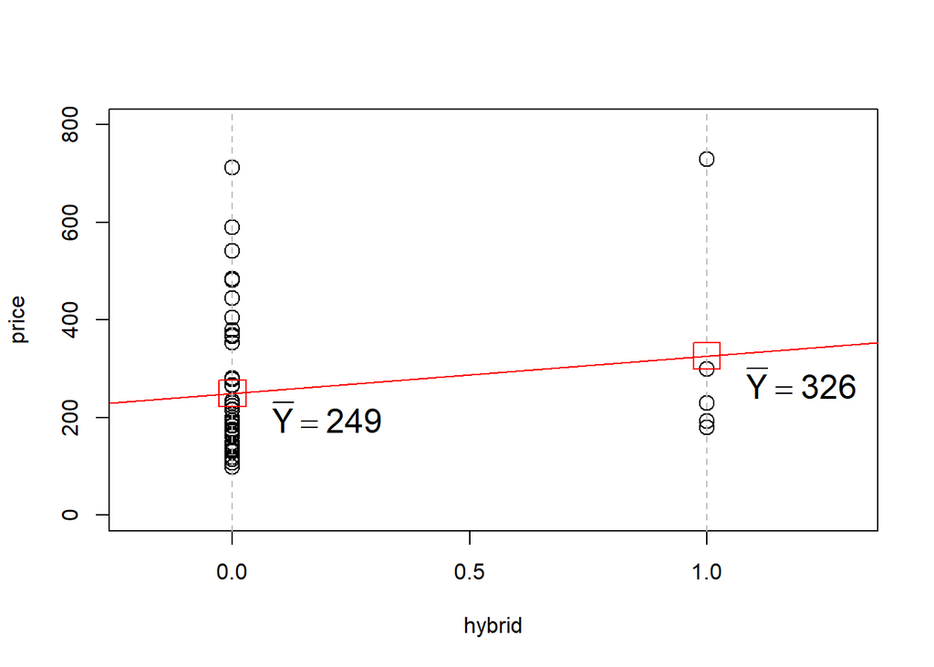

条件分岐によってダミー変数を作ることもできる．

- `ifelse(論理演算, TRUE の場合の値, FALSE の場合の値)` のように指定する．

```r
car$recent <- ifelse(car$year >= 2022, 1, 0)  # = 1 if recent model
table(car$recent)
```

```
##
##  0  1
## 39 11
```

```r
lm(price ~ weight + recent, car)$coef
```

```
##  (Intercept)       weight       recent
## -167.9950335    0.3574592   33.0305631
```

## 4.2 Quadratic and interaction terms / 二次・交差項

$$\mbox{Price} = \alpha + \beta_1 \
\mbox{PS} + \beta_2 \ \mbox{PS}^2 + u$$

```r
car$ps2 <- car$ps^2
lm(price ~ ps + ps2, car)$coef
```

```
## (Intercept)          ps         ps2
##  3.90668080  2.82808263 -0.00307522
```

上の回帰式は次のような非線形な関係（二乗項の係数が負なので上に凸の二次関数）を表す．

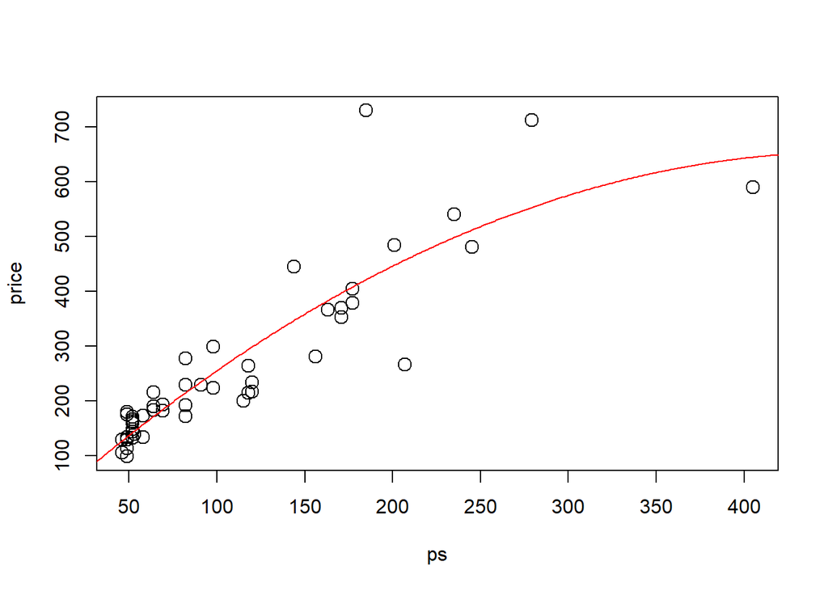

データセットを直接操作せずに，回帰モデルを指定する際に `I` 関数を使って二乗項を表現することもできる．

```r
lm(price ~ ps + I(ps^2), car)$coef
```

```
## (Intercept)          ps     I(ps^2)
##  3.90668080  2.82808263 -0.00307522
```

$$\mbox{Price} = \alpha + \beta_1 \
\mbox{Weight} + \beta_2 \ \mbox{Hybrid} + \beta_3 \ \mbox{Weight} \times
\mbox{Hybrid} + u$$

```r
car$wh <- car$weight * car$hybrid
lm(price ~ weight + hybrid + wh, car)$coef
```

```
##  (Intercept)       weight       hybrid           wh
## -148.6298253    0.3441707 -168.3087621    0.1583126
```

このように，交差項を用いることでカテゴリー（この場合はハイブリッド車とガソリン車（・ディーゼル車））による回帰係数の異質性を表現できる．

$$\mbox{Price} = -149 + 0.34
\mbox{Weight} - 168 \mbox{Hybrid} + 0.16 \mbox{Weight} \times
\mbox{Hybrid} + u$$
$$= \left\{
\begin{array}{l} -317 + 0.50 \mbox{Weight} + u \quad \mbox{if} \quad
\mbox{Hybrid} \\ -149 + 0.34 \mbox{Weight} + u \quad \mbox{if} \quad
\mbox{Not Hybrid} \end{array} \right.$$

「`var1 : var2`」は「`var1 × var2`」を表し，「`var1 * var2`」は「`var1 + var2 + (var1 × var2)`」を表す．

```r
lm(price ~ weight + hybrid + weight:hybrid, car)$coef
```

```
##   (Intercept)        weight        hybrid weight:hybrid
##  -148.6298253     0.3441707  -168.3087621     0.1583126
```

```r
lm(price ~ weight*hybrid, car)$coef
```

```
##   (Intercept)        weight        hybrid weight:hybrid
##  -148.6298253     0.3441707  -168.3087621     0.1583126
```

## 4.3 Log-linear model

$$\log(\mbox{Price}) = \alpha + \beta \
\mbox{Weight} + u$$

説明変数や被説明変数に対数を取る場合は `I` なしで `log` を使ってよい．

```r
lm(log(price) ~ weight, car)$coef
```

```
## (Intercept)      weight
## 3.941721733 0.001258482
```

アウトカムに自然対数を取る場合，「$x$ が1単位大きな値を取る時に $y$ が $(100 \times \beta)$ % 高い値を取る」と解釈される．

$$\beta = \frac{\partial
\log(y)}{\partial x} = \frac{\partial \log(y)}{\partial y}
\frac{\partial y}{\partial x} = \frac{1}{y} \frac{\partial y}{\partial
x} = \frac{\partial y / y}{\partial x}$$

よって，「1 kg重い自動車の価格は約0.13%高い」と解釈できる．

- なお，上は $\beta$ が0に近い値（たとえば 0.01 や 0.001 くらいのオーダー）を取る場合にはよい近似となる．0から離れた値（たとえば 0.5 またはそれ以上）を取る場合は $\exp(\beta) - 1$ で厳密に計算するとよい．
- $y = f(x) = \exp(\alpha + \beta x)$ とすると，下の式より「$x$ が1単位大きな値を取る時に $y$ が $(100 \times [\exp(\beta)-1])$ % 高い値を取る」と計算できる．

$$\Delta \% := 100 \times \frac{f(x+1) -
f(x)}{f(x)} = 100 \times \frac{\exp(\alpha + \beta (x+1)) - f(x)}{f(x)}$$
$$= 100 \times \frac{f(x) \cdot
\exp(\beta) - f(x)}{f(x)} = 100 \times [ \exp(\beta) - 1 ]$$

## 4.4 Log-log model

$$\log(\mbox{Price}) = \alpha + \beta \
\log(\mbox{Weight}) + u$$

```r
lm(log(price) ~ log(weight), car)$coef
```

```
## (Intercept) log(weight)
##   -5.342678    1.533081
```

両辺に対数を取る場合は「$x$ が 1% 大きな値を取る時に $y$ が $\beta$ % 高い値を取る」と解釈される．

- $\beta$ は経済学では弾力性として知られる．

$$\beta = \frac{\partial
\log(y)}{\partial \log(x)} = \frac{\partial \log(y)}{\partial y}
\frac{\partial x}{\partial \log(x)} \frac{\partial y}{\partial x} =
\frac{x}{y} \frac{\partial y}{\partial x} = \frac{\partial y /
y}{\partial x / x}$$

「1%重い自動車の価格は約1.5%高い」と解釈できる．

## 4.5 Categorical variables

複数の値を持つカテゴリー変数（質的変数）はダミー変数化する（0-1 の量的変数に変換する）ことで回帰式に含めることができる．

いずれか一つのカテゴリーをベースラインとする（定数項に加えてすべてのカテゴリーをダミー変数として含めると多重共線性により推定できなくなるため，一つは除外しなければならない）．

`maker` 変数はカテゴリー変数なので，これをダミー変数にしてみよう． ダイハツをベースライン（reference group）とする．

```r
table(car$maker)
```

```
##
## Daihatsu    Honda    Mazda   Nissan   Subaru   Suzuki   Toyota
##        7        6        1        7        3       10       16
```

```r
car$Honda <- 1 * (car$maker == "Honda")
car$Mazda <- 1 * (car$maker == "Mazda")
car$Nissan <- 1 * (car$maker == "Nissan")
car$Subaru <- 1 * (car$maker == "Subaru")
car$Suzuki <- 1 * (car$maker == "Suzuki")
car$Toyota <- 1 * (car$maker == "Toyota")
head(car[, c("maker", "Honda", "Mazda", "Nissan", "Subaru", "Suzuki", "Toyota")])
```

| maker | Honda | Mazda | Nissan | Subaru | Suzuki | Toyota |
| --- | --- | --- | --- | --- | --- | --- |
| Honda | 1 | 0 | 0 | 0 | 0 | 0 |
| Toyota | 0 | 0 | 0 | 0 | 0 | 1 |
| Daihatsu | 0 | 0 | 0 | 0 | 0 | 0 |
| Toyota | 0 | 0 | 0 | 0 | 0 | 1 |
| Suzuki | 0 | 0 | 0 | 0 | 1 | 0 |
| Suzuki | 0 | 0 | 0 | 0 | 1 | 0 |

```r
lm(price ~ weight + Honda + Mazda + Nissan + Subaru + Suzuki + Toyota, car)$coef
```

```
##  (Intercept)       weight        Honda        Mazda       Nissan       Subaru
## -192.7228606    0.4035732  -16.8371837 -147.6797964  -28.2007247  -87.1606913
##       Suzuki       Toyota
##    3.0663751  -26.1403619
```

たとえば，`Honda` の回帰係数 -17 は，ホンダの車がベースラインであるダイハツの車と比較して 17 万円低いことを表している（ただし統計的に有意ではない）．

`lm` 関数にカテゴリー変数をそのまま含めると自動的に水準別ダミー変数が作成され推定される．

```r
lm(price ~ weight + maker, car)$coef
```

```
##  (Intercept)       weight   makerHonda   makerMazda  makerNissan  makerSubaru
## -192.7228606    0.4035732  -16.8371837 -147.6797964  -28.2007247  -87.1606913
##  makerSuzuki  makerToyota
##    3.0663751  -26.1403619
```

### 4.5.1 Change the reference group

ベースラインのカテゴリーを変更するには `relevel` 関数を使う．

```r
car$maker <- relevel(as.factor(car$maker), ref = "Honda")
lm(price ~ weight + maker, car)$coef
```

```
##   (Intercept)        weight makerDaihatsu    makerMazda   makerNissan
##  -209.5600443     0.4035732    16.8371837  -130.8426127   -11.3635410
##   makerSubaru   makerSuzuki   makerToyota
##   -70.3235076    19.9035588    -9.3031782
```

今度は，ダイハツがベースラインのホンダと比較して 17 万円高いと解釈できる．

## 4.6 Centering

$X^c = X - \bar{X}$ とするとき，モデルの決定係数と回帰直線そのものは変わらないが，一部の係数の推定値と統計的有意性は変わる．

cf. 前掲「Standardized partial regression coefficient / 標準偏回帰係数」

例１：

$$\mbox{Price} = \alpha + \beta \
\mbox{Width} + u,$$
$$\mbox{Price} =
\alpha^c + \beta^c \ \mbox{Width}^c + u = (\alpha^c - \beta^c \
\bar{\mbox{Width}}) + \beta^c \ \mbox{Width} + u$$

- $\hat{\alpha}$ は Width=0 における Price の平均であるが，$\hat{\alpha}^c$ は Width=mean(Width) における Price の平均を表す．係数はもちろん標準誤差も異なるので，統計的有意性も異なる．
- $\hat{\beta}$ と $\hat{\beta}^c$ はどちらも Width が1単位大きい値を取る時に Price がどれだけ大きい／小さい値を取るかを表す．係数の推定値も標準誤差も同じなので，統計的有意性も当然同じ．

```r
lm1 <- lm(price ~ width, car)
lm2 <- lm(price ~ I(width - mean(width)), car)
huxtable::huxreg(lm1, lm2)
```

|  | (1) | (2) |
| --- | --- | --- |
| (Intercept) | -974.501 *** | 257.070 *** |
|  | (135.563) | (13.135) |
| width | 746.497 *** |  |
|  | (81.783) |  |
| I(width - mean(width)) |  | 746.497 *** |
|  |  | (81.783) |
| N | 50 | 50 |
| R2 | 0.634 | 0.634 |
| logLik | -296.490 | -296.490 |
| AIC | 598.980 | 598.980 |
| *** p < 0.001; ** p < 0.01; * p < 0.05. |  |  |

```r
lm2$coef[1] - lm2$coef[2] * mean(car$width)  # should be identical to alpha in model (1)
```

```
## (Intercept)
##   -974.5008
```

例２：

$$\mbox{Price} = \alpha + \beta_1 \
\mbox{Width} + \beta_2 \ \mbox{Weight} + \beta_3 \ \mbox{Width} \times
\mbox{Weight} + u \\ = \alpha + \beta_1 \ \mbox{Width} + (\beta_2 +
\beta_3 \ \mbox{Width} ) \mbox{Weight} + u,$$
$$\mbox{Price} = \alpha^c + \beta_1^c \
\mbox{Width}^c + \beta_2^c \ \mbox{Weight} + \beta_3^c \ \mbox{Width}^c
\times \mbox{Weight} + u \\ = \alpha^c + \beta_1^c \ \mbox{Width}^c +
(\beta_2^c + \beta_3^c \ \mbox{Width}^c) \mbox{Weight} + u$$

- Weight が1単位大きい値を取るときにどれだけ Price が異なる値を取るかが Width によって異なる（Weight の係数に異質性がある）ことを表現するために，交差項を用いる．
- Centering しない場合，$\hat{\beta}_2$ は Width=0 における Weight の係数として解釈される．Width 変数は平均 1.7（最小 1.5，最大 1.9）であり，Width=0 における係数は解釈が難しい．下に示す通りこの係数は負に推定されており（重いほど安い），これは直感に反する．
- Centering する場合，$\hat{\beta}_2^c$ は Width=mean(Width) における Weight の係数として解釈される．直感通り正に推定されている．
- 交差項の係数（・標準誤差）は Centering の影響を受けない．

```r
lm2 <- lm(price ~ weight*width, car)
lm3 <- lm(price ~ weight*I(width - mean(width)), car)
huxtable::huxreg(lm2, lm3)
```

|  | (1) | (2) |
| --- | --- | --- |
| (Intercept) | 850.092 * | -116.498 |
|  | (422.119) | (82.886) |
| weight | -0.634 | 0.293 *** |
|  | (0.483) | (0.079) |
| width | -585.883 * |  |
|  | (242.722) |  |
| weight:width | 0.562 * |  |
|  | (0.257) |  |
| I(width - mean(width)) |  | -585.883 * |
|  |  | (242.722) |
| weight:I(width - mean(width)) |  | 0.562 * |
|  |  | (0.257) |
| N | 50 | 50 |
| R2 | 0.845 | 0.845 |
| logLik | -274.973 | -274.973 |
| AIC | 559.945 | 559.945 |
| *** p < 0.001; ** p < 0.01; * p < 0.05. |  |  |

# 5 Prediction / 予測

当てはめ値は定義通り次のように計算できる．

$$\hat{Y}_i = \hat{\alpha} + \hat{\beta}
X_i$$

```r
lm(price ~ weight + ps, car)$coef
```

```
##  (Intercept)       weight           ps
## -103.7104391    0.2367862    0.7764891
```

```r
car$pred0 <- -103.71 + 0.2368 * car$weight + 0.7765 * car$ps
head(car[, c("model", "price", "pred0")], 3)
```

| model | price | pred0 |
| --- | --- | --- |
| N-BOX | 174 | 157 |
| Prius | 299 | 294 |
| Tanto | 148 | 145 |

- `lm(y ~ x, data)$fitted.value` はアウトカム変数 and/or 説明変数の欠損により除外された個体を含まないベクトルのため，元のデータセットと行数が合わないことがある．

たとえば {1,000 kg, 100 ps} という仮想的な車種の価格を予測するには，上の計算式にこの属性値を代入すればよい．

```r
-103.71 + 0.2368 * 1000 + 0.7765 * 100
```

```
## [1] 210.74
```

## 5.1 `predict` function

推定に用いたサンプルの当てはめ値も，out-of-sample の予測も，`predict` 関数で計算できる．

- 予測値を元のデータセットにマージしたい場合，変数に欠損値があると予測値ベクトルのサイズが元のデータセットの行数より小さくなってしまうため，次のように `na.action = na.exclude` オプションを追加する．

```r
lm1 <- lm(price ~ weight + ps, car, na.action = na.exclude)
car$pred1 <- predict(lm1, newdata = car)
# car[, c("model", "price", "pred0", "pred1")] |> head(3)
knitr::kable(car[, c("model", "price", "pred0", "pred1")] |> head(3))
```

|  | model | price | pred0 | pred1 |
| --- | --- | --- | --- | --- |
| 1 | N-BOX | 173.9 | 156.815 | 156.8014 |
| 3 | Prius | 299.0 | 294.435 | 294.4147 |
| 4 | Tanto | 148.5 | 145.052 | 145.0388 |

```r
predict(lm1, newdata = data.frame(weight = 1000, ps = 100))
```

```
##        1
## 210.7247
```

## 5.2 Inverse transformation of log outcomes

Log-linear model の場合，予測値を元の変数のスケールに戻すには次のようにする．

- Step 1. $y \to \log y$
- Step 2. $\log y = \alpha + \beta x + u$
  - 仮定：（$y$ ではなく）$\log y$ は（$x$ で条件付けたもとで）正規分布に従う．
- Step 3. $\widehat{\log y} = \hat{\alpha} + \hat{\beta} x$
  - 当てはめ値は $\widehat{\log{(y)}}$ （対数スケール上の当てはめ値）であって $\log{(\hat{y})}$ （元スケール上の予測値の対数）ではないことに注意．
- Step 4.
  $$\hat{y} = \exp \left(
  \hat{\log{y}} + \frac{\sigma^2}{2} \right)$$
  - この式は $z \sim N(\mu, \sigma^2)$ のとき $E(\exp z) = \exp(\mu + \sigma^2/2)$ となることから導出される．
  - $\sigma^2$ は誤差分散．真の値は未知なので残差の分散（正確には，誤差分散の不偏推定量になるように調整したもの）で代用する．$K$ は定数項を除いた説明変数の数．

$$\hat{\sigma}^2 = \frac{1}{n - K - 1}
\sum_{i = 1}^n \hat{u}_i^2 \quad \mbox{where} \quad \hat{u}_i =
\log(Y_i) - \widehat{\log(Y_i)}$$

```r
## correct way
lm0 <- lm(log(price) ~ weight + ps, car, na.action = na.exclude)
sigma2 <- sum(lm0$residuals^2) / (length(lm0$residuals) - 3)
# sigma2 <- summary(lm2)$sigma^2  # same as above
car$pred_correct <- exp(predict(lm0, newdata = car) + sigma2/2)
## incorrect way
car$pred_incorrect <- exp(predict(lm0, newdata = car))
# head(car[, c("model", "price", "pred_correct", "pred_incorrect")], 3)
knitr::kable(head(car[, c("model", "price", "pred_correct", "pred_incorrect")], 3))
```

|  | model | price | pred_correct | pred_incorrect |
| --- | --- | --- | --- | --- |
| 1 | N-BOX | 173.9 | 162.3229 | 160.4902 |
| 3 | Prius | 299.0 | 266.4931 | 263.4843 |
| 4 | Tanto | 148.5 | 156.0345 | 154.2728 |

上のような補正を行わないと予測値が過小評価される． このことを次のように平均値で確認する．

```r
car2 <- car[!is.na(car$ps), ]  # 欠損のある車種は推定に使われていないので除外
c(mean(car2$price), mean(car2$pred_correct), mean(car2$pred_incorrect))
```

```
## [1] 259.8918 260.2486 257.3103
```

# 6 Model selection / モデル選択

被説明変数の予測を目的として回帰分析を行う場合，複数のモデル候補があった場合に，予測力が最も優れたモデルを一つ選択したい場合があるだろう． しかし，説明変数を追加すれば決定係数は必ず増加するが，それは標本に特有のデータの変動（あるいはノイズ）に過適合しているだけかもしれない． この過適合によって説明変数過剰のモデルが選択されることを防ぐために，モデルの説明力とモデルの簡潔さのトレードオフの間でバランスを取るための何らかの指標が必要となる．

## 6.1 AIC

実務的に広く利用されるのはAIC（赤池情報量規準）と呼ばれる規準． これはモデルを最尤推定することを前提として「最尤推定量の対数尤度」と「パラメタの数（＝定数項を含む説明変数の数＝K+1）」のトレードオフとして記述される．

$$AIC = -2 \log L + 2(K+1)$$

対数尤度は大きいほどモデルのデータへの当てはまりが良く，principle of parsimony の観点からパラメタ数は少ない方がよい． すなわち，複数のモデル間で AIC が最も小さいモデルが望ましい．

注：

- 因果推論を目的として回帰分析を行う場合には一般にモデル選択は行わない場合が多い．分析の目的に応じてモデル選択を行うかどうかを決めよう．
  - 典型的な AIC の使いどころは時系列分析におけるラグの次数決定．
- AICは「真のモデル」を選択する基準ではない．あくまで予測力の観点で（比較対象の中で相対的に最も）望ましいモデルを選択する基準である．
- 「AICは入れ子関係のモデル間の比較にしか使えない」という主張に稀に出くわすが，それは誤り．入れ子関係のモデル間でないと適用できない一部の検定と混同されているものと思われる．詳しくは Burnham and Anderson (2002) [Model Selection and Multimodel Inference](https://link.springer.com/book/10.1007/b97636) (Ch. 2) などを参照．
- モデル選択後に回帰係数の検定は行わない．少なくとも，オーソドックスな t 検定をナイーブに適用するのはNG．

データセットが欠損値を含むため `na.omit` 関数を使って欠損値を含む行を予めすべて削除する．

```r
lm1 <- lm(price ~ weight, na.omit(car))
lm2 <- lm(price ~ weight + ps, na.omit(car))
lm3 <- lm(price ~ weight + ps + length + width, na.omit(car))
AIC(lm1, lm2, lm3)
```

| df | AIC |
| --- | --- |
| 3 | 507 |
| 4 | 497 |
| 6 | 498 |

2つ目のモデルの値が最も小さいが，2つ目と3つ目の差は十分に小さい（経験則として2を下回っている）ため，2つ目と3つ目のモデルはほとんど同程度と判断できる．

## 6.2 Stepwise model selection with AIC

考え得る説明変数をすべて含めたモデル (full model) からスタートして stepwise で最適なモデルを選択することもできる．

`step` 関数を使うと AIC を規準としてモデル選択が行われる．

```r
lm_full <- lm(price ~ weight + length + width + height + WLTC +
                ps + disp + hybrid + accel + kei + maker, na.omit(car))
lm_step <- step(lm_full, trace = 0)  # trace = 1 にすると計算過程が出力される
# AIC(lm_step)
summary(lm_step)$coef
```

```
##                  Estimate   Std. Error   t value     Pr(>|t|)
## (Intercept)  -587.5679793 4.571500e+02 -1.285285 0.2071329299
## weight          0.2067181 1.238871e-01  1.668601 0.1041196936
## length       -168.6160919 8.209700e+01 -2.053864 0.0475182032
## width         996.5137653 3.534776e+02  2.819171 0.0078717951
## height       -219.0329144 6.892895e+01 -3.177662 0.0030983378
## ps              3.1288058 8.913864e-01  3.510044 0.0012534436
## disp           -0.1232391 4.430405e-02 -2.781667 0.0086526134
## hybrid         92.0504882 2.474967e+01  3.719262 0.0006973619
## accel       -3186.4444056 1.496767e+03 -2.128884 0.0403765717
## kei           147.3452243 5.329504e+01  2.764708 0.0090288881
```

しかし符号が直感と反する変数が幾つかある． VIFをチェックすると案の定多重共線性が生じている．

```r
car::vif(lm_step)
```

```
##     weight     length      width     height         ps       disp     hybrid
##  55.871573  54.803133  81.432658   2.273168 110.198829  22.175713   1.508772
##      accel        kei
##  65.599128  17.280466
```

## 6.3 Cross validation / 交差検証

回帰モデルの予測性能（汎化性能）を評価するための手法として交差検証はよく用いられる． 交差検証ではデータを「推定用」と「評価用」に分割し，推定用のサブサンプルで推定されたモデルの性能を評価用のサブサンプル（out-of-sample）で評価する．

- 機械学習の文脈では訓練データ・検証データ・テストデータと区別するが，ここでは検証データで最終評価を行う（テストデータのように扱う）場合を考える．

この演習で使っている `car` データはサンプルサイズが小さいため，評価用のサブサンプルはサイズ1としよう．

評価指標には MSE (mean squared error) を用いる． MSE の標本対応は次の通り． $\hat{Y}_i$ は $i$ 以外のデータ（すなわち $1,2,\ldots,i-2,i-1,i+1,i+2,\ldots,n$）によって推定されたモデルのパラメタ（$\hat{\alpha}_{-i}, \hat{\beta}_{-i}$）に基づいて予測された $i$ の値である．

$$\mbox{MSE} = \frac{1}{n} \sum_{i = 1}^n
(Y_i - \hat{Y}_i)^2 \quad \mbox{where} \quad \hat{Y}_i =
\hat{\alpha}_{-i} + \hat{\beta}_{-i} \ X_i$$

つまり，以下のように Step 1, Step 2, …, Step n を実行し，二乗誤差の平均値を計算する．

- Step 1. $i=2,\ldots,n$ を推定用，$i=1$ を評価用として，二乗誤差を計算
- Step 2. $i=1,3,\ldots,n$ を推定用，$i=2$ を評価用として，二乗誤差を計算
- Step 3. $i=1,2,4,\ldots,n$ を推定用，$i=3$ を評価用として，二乗誤差を計算
- Step 4. $i=1,2,3,5,\ldots,n$ を推定用，$i=4$ を評価用として，二乗誤差を計算
- …
- Step n. $i=1,\ldots,n-1$ を推定用，$i=n$ を評価用として，二乗誤差を計算

このような交差検証を Leave-One-Out CV と呼ぶ．

説明変数が少ないモデル（alternative model）の方が予測誤差が小さい． これは full model で生じている深刻な多重共線性が幾つかの変数削除によって解消されたため（そして，それによる予測力の向上が説明変数を減らすことによる説明力の低下を相殺してなお上回るため）であると考えられる．

```r
car2 <- na.omit(car)
se <- NULL
for (i in 1:nrow(car2)) {
  # Full model
  lm_full_i <- lm(price ~ weight + length + width + height + WLTC +
                    ps + disp + hybrid + accel + kei + year, car2[-i,])
  pred_full_i <- as.numeric(predict(lm_full_i, newdata = car2[i, ]))  # hat{y}_i
  se_full_i <- (car2$price[i] - pred_full_i)^2  # (squared error)_i
  # Alternative model
  lm_alt_i <- lm(price ~ weight + height + ps + hybrid + kei + year, car2[-i,])
  pred_alt_i <- as.numeric(predict(lm_alt_i, newdata = car2[i, ]))
  se_alt_i <- (car2$price[i] - pred_alt_i)^2
  # stack
  se <- rbind(se, c(id = i, price = car2$price[i],
                    pred_full = pred_full_i, se_full = se_full_i,
                    pred_alt = pred_alt_i, se_alt = se_alt_i))
}
summary(se[, c(4, 6)])
```

```
##     se_full             se_alt
##  Min.   :    4.12   Min.   :    1.46
##  1st Qu.:  261.67   1st Qu.:  314.94
##  Median : 1315.18   Median : 1281.30
##  Mean   : 3356.59   Mean   : 2916.42
##  3rd Qu.: 2707.38   3rd Qu.: 2758.49
##  Max.   :41321.30   Max.   :34592.28
```

```r
# plot(pred_full ~ price, se, cex = 1.5); abline(a = 0, b = 1, col = "red")
# plot(pred_alt ~ price, se, cex = 1.5); abline(a = 0, b = 1, col = "red")
```

単位を万円に戻すためにMSEの平方根をとると，Full model では 58 万円，Alternative model では 54 万円となる．

```r
c(sqrt(3356.59), sqrt(2916.42))  # RMSE (Root MSE)
```

```
## [1] 57.93609 54.00389
```

Alternative model は以下のように推定される．

```r
lm_alt <- lm(price ~ weight + height + ps + hybrid + kei + year, car2)
summary(lm_alt)$coef
```

```
##                  Estimate   Std. Error   t value     Pr(>|t|)
## (Intercept) -1.711715e+04 4.178485e+03 -4.096495 2.118593e-04
## weight       2.949684e-01 3.916656e-02  7.531128 4.755765e-09
## height      -1.284230e+02 5.828417e+01 -2.203395 3.370089e-02
## ps           8.867450e-01 1.760835e-01  5.035935 1.186617e-05
## hybrid       3.924293e+01 2.183725e+01  1.797064 8.027690e-02
## kei          8.514798e+01 2.203004e+01  3.865086 4.204883e-04
## year         8.469391e+00 2.069523e+00  4.092435 2.144453e-04
```

```r
car::vif(lm_alt)
```

```
##   weight   height       ps   hybrid      kei     year
## 5.589411 1.626768 4.304064 1.175648 2.955349 1.189786
```

これでもなお不安な符号が幾つか残っているが（全高 `height` が負，軽自動車ダミー `kei` が正），何らかの除外変数によるものなのか，あるいはこの符号で実際に正しいのかは不明．

# 7 Take-home messages

- 回帰分析：`summary(lm(formula = Y ~ X1 + X2, data = dataset))`
- 最小二乗法とは誤差（残差）の二乗が小さくなるように係数パラメタを求める原理
- XがYに与える影響を推定しようとする場合，どのような変数をコントロールしなければならないか，逆にどのような変数はコントロールしてはならないか，を熟考する
- ダミー変数を用いることで，質的変数（カテゴリー変数として記述される情報）を回帰分析の枠組みに組み込むことができる